# Individual2

Muhammad Idris

9/13/2020

## Reading the data

```r
choco <- read.csv("https://raw.githubusercontent.com/xdaiISU/ds202materials/master/hwlabs/data/choco.csv")
str(choco)
```

```
## 'data.frame':    2312 obs. of  13 variables:
##  $ REF                 : int  2454 2458 2454 797 797 1015 1019 1011 1019 1011 ...
##  $ Company             : chr  "5150" "5150" "5150" "A. Morin" ...
##  $ Location            : chr  "U.S.A." "U.S.A." "U.S.A." "France" ...
##  $ Date                : int  2019 2019 2019 2012 2012 2013 2013 2013 2013 2013 ...
##  $ Bean_Origin         : chr  "Madagascar" "Dominican Republic" "Tanzania" "Peru" ...
##  $ Specific_Bean_Origin: chr  "Bejofo Estate, batch 1" "Zorzal, batch 1" "Kokoa Kamili, batch 1" "Peru" ...
##  $ Cocoa_Percent       : num  76 76 76 63 70 70 63 70 70 70 ...
##  $ Ingredients         : chr  "3- B,S,C" "3- B,S,C" "3- B,S,C" "4- B,S,C,L" ...
##  $ Characteristics1    : chr  "cocoa" "cocoa" "rich cocoa" "fruity" ...
##  $ Characteristics2    : chr  "blackberry" "vegetal" "fatty" "melon" ...
##  $ Characteristics3    : chr  "full body" "savory" "bready" "roasty" ...
##  $ Characteristics4    : chr  NA NA NA NA ...
##  $ Rating              : num  3.75 3.5 3.25 3.75 3.5 4 4 3.75 3.5 3.25 ...
```

## Searching for the Best Chocolates

1. How are the ratings distributed? Create both a histogram and a boxplot and describe them. Don’t forget to mention outliers, if there are any.

#Histogram of Cocoa rating distribution

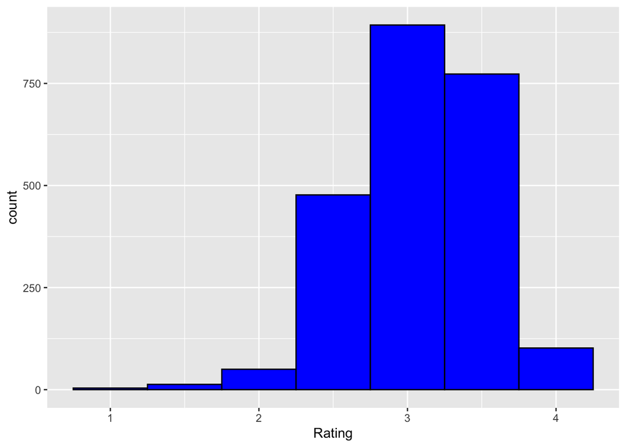

```r
library(ggplot2)

chocHist <-ggplot(choco, aes(x = Rating)) +
  geom_histogram(binwidth = 0.5, color="black", fill="blue")

chocHist
```

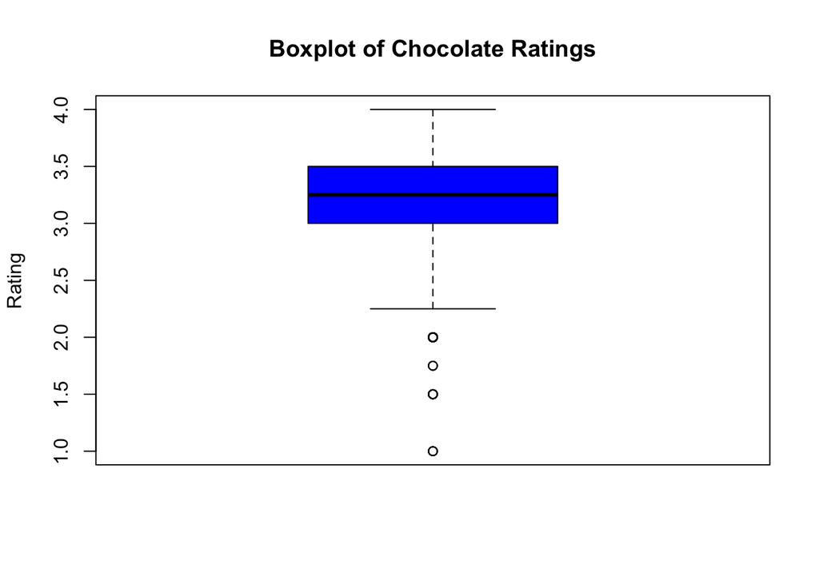

```r
boxplot(choco[,'Rating'], ylab = "Rating", main = "Boxplot of Chocolate Ratings", col="blue")
```

Chocolate rating looks normally distributed with some outliers.

2. How does the number of ratings depend on the year? Draw a bar chart of the number of reports.

#Bar chart of Cocoa rating by year

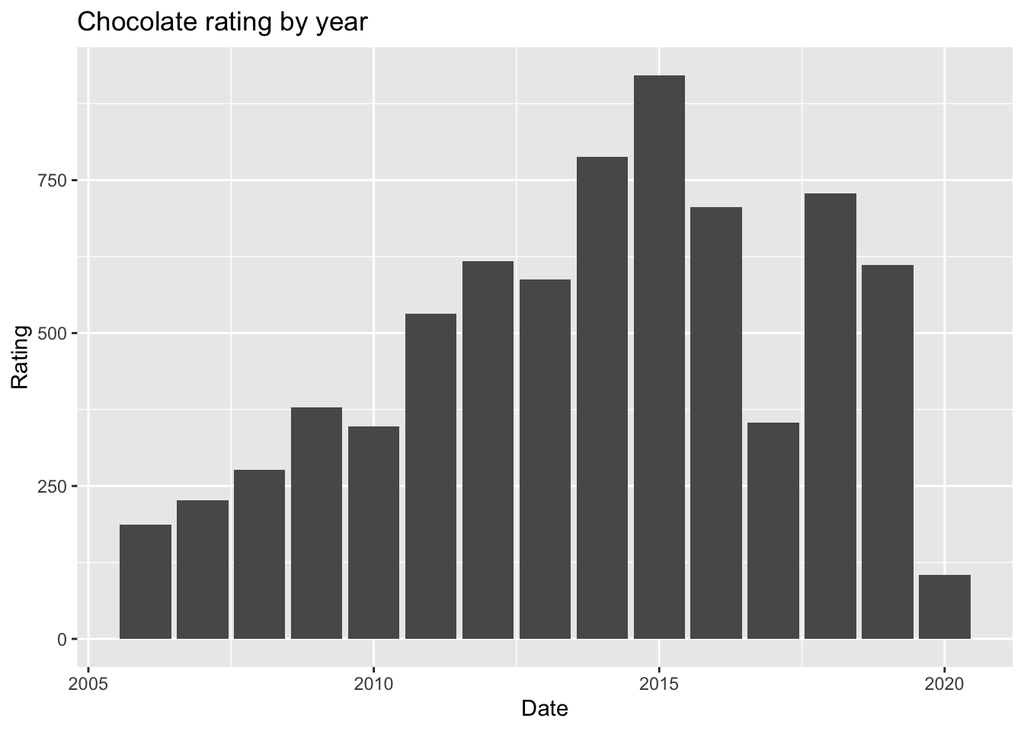

```r
ggplot(choco, aes(y = Rating, x = Date)) +
  geom_bar(stat = "identity") + ggtitle(label = "Chocolate rating by year")
```

Ratings look like they increase until 2015 but has a consoderable drop in 2020.

3. Do ratings depend on the cacao percentage of a chocolate bar? Create both numerical and graphical summaries, and explain.

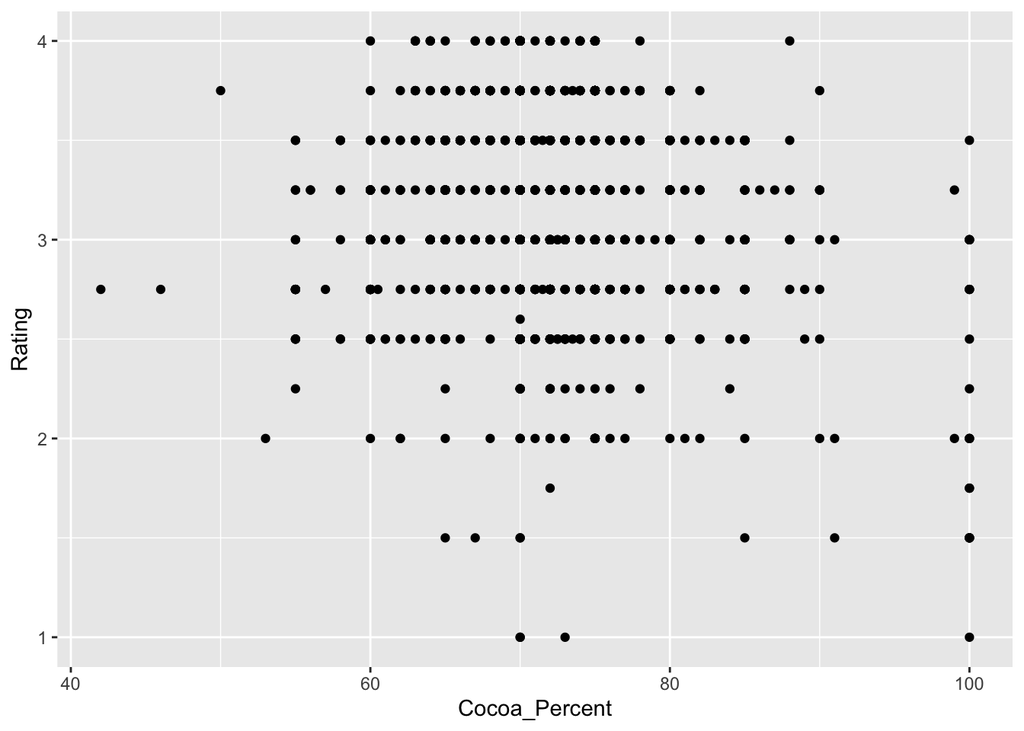

```r
ggplot(choco,aes(x = Cocoa_Percent, y = Rating)) + geom_point()
```

```r
summary(choco$Cocoa_Percent)
```

```
##    Min. 1st Qu.  Median    Mean 3rd Qu.    Max.
##   42.00   70.00   70.00   71.65   75.00  100.00
```

It looks like the chocolate ratings do not depend on the cocoa content since there is no trend. The average cocoa content is 71.7% and the values range from 42% to 100% cocoa content.

4. How do different characteristics of the chocolate compare? To elaborate, which characteristics tend to be more favorable and which ones are not? Create both numerical and graphical summaries, and explain.